# Implementando ICs

João Victor Barroso Mafra

## Os dados

```r
set.seed(12345)

lastfm = read_csv(here::here("data/experimento-lastfm.csv"),
                  col_types = cols(.default = col_double(),
                                   user = col_character()))

lastfm = lastfm %>%
  sample_n(300) %>%
  select(news, old, mediana_pop)

glimpse(lastfm)
```

```
## Observations: 300
## Variables: 3
## $ news        <dbl> 25, 13, 21, 18, 10, 11, 29, 51, 23, 11, 22, 35, 77, …
## $ old         <dbl> 103, 61, 62, 180, 55, 68, 120, 45, 61, 116, 68, 83, …
## $ mediana_pop <dbl> 5.966097, 5.745970, 5.195969, 5.595928, 5.900597, 6.…
```

## Proporção de artistas novos e popularidade

Utilizaremos ICs para estimar duas métricas sobre os usuários do LastFM em geral durante um período de 6 meses. Em ambos os casos faremos isso a partir de uma amostra de 300 usuários. As duas métricas são:

### 1. Qual a proporção de novos artistas em geral escutada por usuários?

Adicionando um novo atributo que representa a proporção de artistas novos escutada pelos usuários nos últimos meses

```r
amostra <- lastfm %>% mutate(proporcao = news/(old + news))
```

Definindo funções necessárias:

Função theta para proporção: Calcula a média amostral

Função bootstrap: Usa a tabela e coleta amostras de mesmo tamanho da amostra original com reposição

```r
set.seed(12345)

funcao_theta_proporcao = function(df) {
  df %>%
    pull(proporcao) %>%
    mean()
}

bootstrap = function(df){
  proporcoes = df %>% pull(proporcao)
  boot <- sample(proporcoes,
                   size = NROW(proporcoes),
                   replace = TRUE)
  return(mean(boot))
}
```

A proporção média da amostra é 0.24, ou seja, para essa amostra em média 24% dos artistas escutados são novos.

```r
theta_c = funcao_theta_proporcao(amostra)
theta_c
```

```
## [1] 0.242366
```

Fazendo as reamostragens com 4000 repetições

```r
set.seed(12345)

repeticoes = 4000

reamostragens = tibble(i = 1:repeticoes) %>%
  mutate(theta_c_s = map_dbl(i, ~ bootstrap(amostra)))
```

Calculando I.C do erro:

Usando um nível de confiança de 95%, vamos calcular o error inferior e o erro superior das 4000 repetições em relação a média amostral. Como mostra a distribuição e conforme esperado, o erro amostral concentra-se próximo do 0.

```r
erro.amostral = reamostragens %>%
  mutate(erro = theta_c_s - theta_c)

intervalo = erro.amostral %>%
  summarise(erro_i = quantile(erro, .025),
            erro_s = quantile(erro, .975))
intervalo
```

| erro_i | erro_s |
| --- | --- |
| -0.01153788 | 0.0118495 |

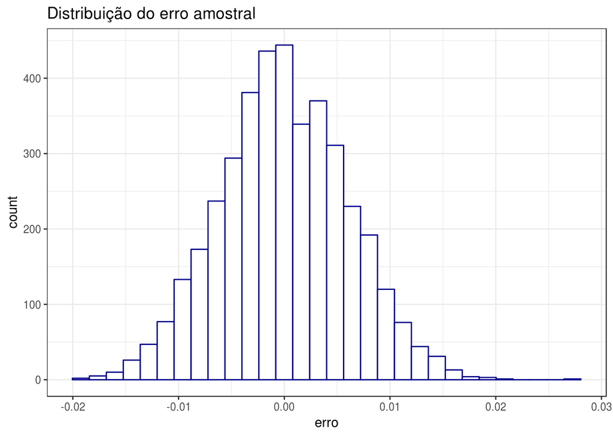

```r
erro.amostral %>%
  ggplot(aes(erro)) +
  geom_histogram(fill = "white",
                 colour = "darkblue") +
  labs(title = "Distribuição do erro amostral")
```

Calculando I.C da proporção média:

Com os erros inferiores e superiores, nós temos o intervalo de confiança para proporção. O resultado mostra que com 95% de confiança, os usuários ouviram em média de 23% a 25% artistas novos. Espera-se portanto que em 95% das vezes a média real da proporção esteja dentro desse intervalo.

```r
ci = intervalo %>%
  mutate(valor_i = theta_c + erro_i,
         valor_s = theta_c + erro_s)
ci
```

| erro_i | erro_s | valor_i | valor_s |
| --- | --- | --- | --- |
| -0.01153788 | 0.0118495 | 0.2308281 | 0.2542155 |

Usando uma função pronta para fazer bootstrap com o mesmo nível de confiança e mesmo número de replicações, obtemos um resultado igual (I.C entre 23% e 25%)

```r
set.seed(12345)
funcao_theta_proporcao_index = function(df,i) {
  df %>%
    slice(i) %>%
    pull(proporcao) %>%
    mean()
}

booted <- boot(data = amostra,
               statistic = funcao_theta_proporcao_index,
               R = 4000)

ci.2 = boot.ci(booted,
          conf = .95,
          type = "bca")

ci.2
```

```
## BOOTSTRAP CONFIDENCE INTERVAL CALCULATIONS
## Based on 4000 bootstrap replicates
##
## CALL :
## boot.ci(boot.out = booted, conf = 0.95, type = "bca")
##
## Intervals :
## Level       BCa
## 95%   ( 0.2308,  0.2542 )
## Calculations and Intervals on Original Scale
```

### 2. Para os usuários que gostam de música muito pop (mediana_pop > 5), qual a correlação entre a popularidade mediana dos artistas escutado e a proporção dos artistas escutados que eram novos.

O primeiro passo é filtrar os usuários que gostam de música muito pop. Depois disso, duas funções são necessárias:

Função theta para correlação: Calcula a correlação entre as variáveis mediana da popularidade e proporção usando o método de spearman, que busca encontrar uma relação não necessariamente linear entre as duas variáveis.

Função bootstrap: Usa a tabela e coleta amostras de mesmo tamanhos da amostra original com reposição

```r
set.seed(12345)

amostra.pop <- amostra %>% filter(mediana_pop > 5)

funcao_theta_cor = function(df) {
  cor(df$mediana_pop, df$proporcao, method = "spearman")
}

bootstrap_cor = function(df){
  boot <- sample_n(df,           # amostre dos dados
                   size = NROW(df), # tamanho igual ao recebido
                   replace = TRUE) # aqui é o bootstrap
  return(cor(boot$mediana_pop, boot$proporcao, method = "spearman"))
}
```

```r
theta_cor = funcao_theta_cor(amostra.pop)
theta_cor
```

```
## [1] 0.002998545
```

Fazendo as reamostragens com 4000 repetições

```r
set.seed(12345)

reamostragens.cor = tibble(i = 1:repeticoes) %>%
  mutate(theta_c_s = map_dbl(i, ~ bootstrap_cor(amostra.pop)))
```

Calculando I.C do erro:

Usando um nível de confiança de 95% temos o erro inferior e superior para essa correlação observada na amostra.

```r
erro.amostral.cor = reamostragens.cor %>%
  mutate(erro = theta_c_s - theta_cor)

intervalo.cor = erro.amostral.cor %>%
  summarise(erro_i = quantile(erro, .025),
            erro_s = quantile(erro, .975))
intervalo.cor
```

| erro_i | erro_s |
| --- | --- |
| -0.1166945 | 0.1149611 |

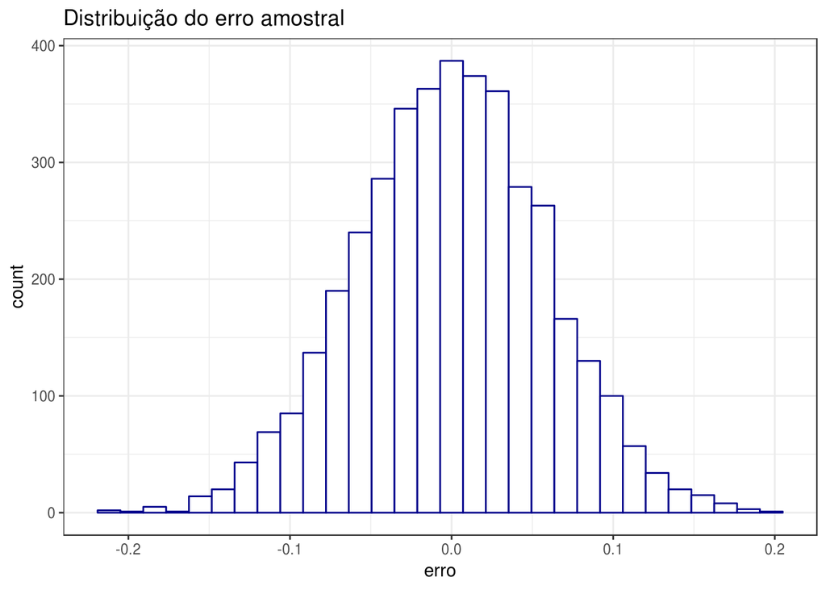

```r
erro.amostral.cor %>%
  ggplot(aes(erro)) +
  geom_histogram(fill = "white",
                 colour = "darkblue") +
  labs(title = "Distribuição do erro amostral")
```

Calculando I.C da correlação entre as duas variáveis:

Com os erros inferiores e superiores, nós temos o intervalo de confiança para correlação O resultado mostra com 95% de confiança, que a correlação entre o fato de o usuário gostar de músicas populares e a proporção de novos artistas escutadas por ele está entre -0.11 e 0.11. Com isso não podemos determinar com certeza se a correlação é positiva ou negativa, mas podemos concluir que é uma correlação muito fraca.

```r
ci.cor = intervalo.cor %>%
  mutate(valor_i = theta_cor + erro_i,
         valor_s = theta_cor + erro_s)
ci.cor
```

| erro_i | erro_s | valor_i | valor_s |
| --- | --- | --- | --- |
| -0.1166945 | 0.1149611 | -0.113696 | 0.1179597 |

Usando uma função pronta para fazer bootstrap com os mesmo parâmetros, obtemos resultados quase iguais (I.C entre -0.11 e 0.11)

```r
set.seed(12345)
funcao_theta_cor_index = function(df,i) {
  df <- df %>%
    slice(i)

  cor(df$mediana_pop, df$proporcao, method = "spearman")
}

booted <- boot(data = amostra.pop,
               statistic = funcao_theta_cor_index,
               R = 4000)

ci.2.cor = boot.ci(booted,
          conf = .95,
          type = "bca")

ci.2.cor
```

```
## BOOTSTRAP CONFIDENCE INTERVAL CALCULATIONS
## Based on 4000 bootstrap replicates
##
## CALL :
## boot.ci(boot.out = booted, conf = 0.95, type = "bca")
##
## Intervals :
## Level       BCa
## 95%   (-0.1126,  0.1186 )
## Calculations and Intervals on Original Scale
```